# Using MR-Base

2016-03-03

## Introduction

Two sample Mendelian randomisation (2SMR) is a method to estimate the causal effect of an exposure on an outcome using only summary statistics from genome wide association studies (GWAS). Though conceptually straightforward, there are a number of steps that are required to perform the analysis properly, and they can be cumbersome. The TwoSampleMR package aims to make this easy by combining three important components

- data management and harmonisation
- the statistical routines to estimate the causal effects
- a large repository of the actual GWAS summary statistics needed to perform the analyses.

The general principles (G. Davey Smith and Ebrahim 2003; George Davey Smith and Hemani 2014), and statistical methods (Pierce and Burgess 2013; Bowden, Davey Smith, and Burgess 2015) can be found elsewhere, here we will just outline how to use the R package.

## Overview

The package implements simple functions to do the following.

1. Get GWAS SNPs for exposure(s)
   - Provide your own instruments or
   - Search through extensive catalogs of instruments
     - GWAS catalog
     - GTEx gene expression QTLs
     - Curated set of SNPs extracted from MR Base
     - Protein QTLs
     - Metabolite QTLs
     - DNA methylation QTLs
2. Perform LD pruning using 1000 genomes data on the MR Base server
3. Get corresponding SNPs for outcome(s)
   - Provide your own GWAS summary stats
   - Search through an extensive collection in the MR Base database
4. Harmonise exposure and outcome associations so effect sizes correspond to the same allele
5. Perform MR and various downstream analyses
   - 10 2SMR methods currently implemented
   - Tests for heterogeneity
   - Tests for directional horizontal pleiotropy
   - Tests for causal direction
   - Single SNP sensitivity analyses
   - Several plotting functions for sensitivity analyses
6. Automatic report generation

## Worked example

Here is a basic example, performing an MR analysis of body mass index (BMI) on type 2 diabetes (T2D). The entire analysis can be performed in the following lines of code:

```r
library(TwoSampleMR)
exposure_dat <- read_exposure_data(system.file("data/bmi.txt", package="TwoSampleMR"), clump=TRUE)
outcome_dat <- extract_outcome_data(exposure_dat$SNP, 6)
dat <- harmonise_data(exposure_dat, outcome_dat)
mr_report(dat)
```

This generates a self contained html file that has the results from a number of MR and sensitivity tests.

### More details

We provide the GWAS SNPs from the 2010 GIANT study on BMI (Speliotes et al. 2010) which can be read in like this:

```r
library(TwoSampleMR)
exposure_dat <- read_exposure_data(system.file("data/bmi.txt", package="TwoSampleMR"))
```

The `read_exposure_data` function is quite flexible, it basically looks for a number of columns, most relevantly `SNP`, `beta`, `se`, `effect_allele` that will be used in MR analysis. It looks up the SNPs in Ensembl biomart to check that they are valid, and imputes missing information where possible. See `?format_data` for more information. This is what the data looks like:

```r
kable(head(exposure_dat))
```

| SNP | beta.exposure | se.exposure | effect_allele.exposure | other_allele.exposure | eaf.exposure | pval.exposure | units.exposure | gene.exposure | samplesize.exposure | exposure | mr_keep.exposure | pval_origin.exposure | units.exposure_dat | id.exposure | chr_name | chrom_start | minor_allele | minor_allele_freq | major_allele | data_source.exposure |
| --- | --- | --- | --- | --- | --- | --- | --- | --- | --- | --- | --- | --- | --- | --- | --- | --- | --- | --- | --- | --- |
| rs10767664 | 0.19 | 0.0306122 | A | T | 0.78 | 0 | kg/m2 | BDNF | 225238 | BMI (kg/m2) | TRUE | reported | kg/m2 | nRJ8CD | 11 | 27725986 | T | 0.2396170 | A | textfile |
| rs13078807 | 0.10 | 0.0204082 | G | A | 0.20 | 0 | kg/m2 | CADM2 | 221431 | BMI (kg/m2) | TRUE | reported | kg/m2 | nRJ8CD | 3 | 85884150 | G | 0.0876597 | A | textfile |
| rs1514175 | 0.07 | 0.0204082 | A | G | 0.43 | 0 | kg/m2 | TNNI3K | 207641 | BMI (kg/m2) | TRUE | reported | kg/m2 | nRJ8CD | 1 | 74991644 | G | 0.3929710 | A | textfile |
| rs1558902 | 0.39 | 0.0204082 | A | T | 0.42 | 0 | kg/m2 | FTO | 222476 | BMI (kg/m2) | TRUE | reported | kg/m2 | nRJ8CD | 16 | 53803574 | A | 0.2280350 | T | textfile |
| rs10968576 | 0.11 | 0.0204082 | G | A | 0.31 | 0 | kg/m2 | LRRN6C | 247166 | BMI (kg/m2) | TRUE | reported | kg/m2 | nRJ8CD | 9 | 28414339 | G | 0.2036740 | A | textfile |
| rs2241423 | 0.13 | 0.0204082 | G | A | 0.78 | 0 | kg/m2 | LBXCOR1 | 227886 | BMI (kg/m2) | TRUE | reported | kg/m2 | nRJ8CD | 15 | 68086838 | A | 0.4051520 | G | textfile |

Next we can perform LD pruning to make sure that we only have independent SNPs. This avoids complications in the MR analysis.

```r
exposure_dat <- clump_data(exposure_dat)
```

Alternatively we could have specified the `clump=TRUE` argument in the `read_exposure_data` function. In this case all the SNPs were already in linkage equilibrium. Next, we can find the 30 BMI SNPs in the type 2 diabetes GWAS summary statistics data. To obtain a list of available GWAS data:

```r
ao <- available_outcomes()
```

Because the data used here is sensitive it is necessary that you sign the data access agreement before the function will complete, a web browser should open prompting you to accept the data access agreement using your gmail account. The `extract_outcome_data` function is used to query MR Base for the requested SNPs against the requested GWAS data. It expects an array of SNPs and an array of GWAS IDs (the `id` column in `ao`). The T2D ID is `6`, so:

```r
outcome_dat <- extract_outcome_data(exposure_dat$SNP, 6)
```

```
## Extracting data for 30 SNP(s) from 1 GWAS(s)
```

Now we can harmonise the exposure and outcome data so that it all corresponds to the same effect allele:

```r
dat <- harmonise_data(exposure_dat, outcome_dat)
```

```
## Harmonising BMI (kg/m2) (nRJ8CD) and T2D || diagram || 2014 (6)
```

[output not shown]

Note that sometimes palindromic SNPs will be excluded from the analysis because there is insufficient information to determine if they are on the same strand. For more details on how to handle this see `?harmonise_data`.

Now that the data is harmonised it is ready to analyse. The following 2SMR methods are currently implemented in the package:

```r
kable(mr_method_list())
```

| obj | name | PubmedID | Description | use_by_default | heterogeneity_test |
| --- | --- | --- | --- | --- | --- |
| mr_wald_ratio | Wald ratio |  |  | TRUE | FALSE |
| mr_meta_fixed_simple | Fixed effects meta analysis (simple SE) |  |  | TRUE | FALSE |
| mr_meta_fixed | Fixed effects meta analysis (delta method) |  |  | TRUE | TRUE |
| mr_meta_random | Random effects meta analysis (delta method) |  |  | TRUE | TRUE |
| mr_two_sample_ml | Maximum likelihood |  |  | TRUE | TRUE |
| mr_egger_regression | MR Egger | 26050253 |  | TRUE | TRUE |
| mr_egger_regression_bootstrap | MR Egger (bootstrap) | 26050253 |  | FALSE | FALSE |
| mr_weighted_median | Weighted median |  |  | TRUE | FALSE |
| mr_penalised_weighted_median | Penalised weighted median |  |  | FALSE | FALSE |
| mr_ivw | Inverse variance weighted |  |  | TRUE | TRUE |

To use these methods to perform the MR, run:

```r
mr_results <- mr(dat)
```

Our results look like this:

```r
kable(mr_results)
```

| id.exposure | id.outcome | outcome | exposure | method | nsnp | b | se | pval |
| --- | --- | --- | --- | --- | --- | --- | --- | --- |
| nRJ8CD | 6 | T2D \|\| diagram \|\| 2014 | BMI (kg/m2) | Fixed effects meta analysis (simple SE) | 30 | 0.2136772 | 0.0183321 | 0e+00 |
| nRJ8CD | 6 | T2D \|\| diagram \|\| 2014 | BMI (kg/m2) | Fixed effects meta analysis (delta method) | 30 | 0.2024843 | 0.0196574 | 0e+00 |
| nRJ8CD | 6 | T2D \|\| diagram \|\| 2014 | BMI (kg/m2) | Random effects meta analysis (delta method) | 30 | 0.1836739 | 0.0253297 | 0e+00 |
| nRJ8CD | 6 | T2D \|\| diagram \|\| 2014 | BMI (kg/m2) | Maximum likelihood | 30 | 0.2155527 | 0.0192924 | 0e+00 |
| nRJ8CD | 6 | T2D \|\| diagram \|\| 2014 | BMI (kg/m2) | MR Egger | 30 | 0.2867196 | 0.0418639 | 2e-07 |
| nRJ8CD | 6 | T2D \|\| diagram \|\| 2014 | BMI (kg/m2) | Weighted median | 30 | 0.2194715 | 0.0314855 | 1e-07 |
| nRJ8CD | 6 | T2D \|\| diagram \|\| 2014 | BMI (kg/m2) | Inverse variance weighted | 30 | 0.2136772 | 0.0222723 | 0e+00 |

There is compelling evidence for a causal association. To visualise how much the different methods differ in their estimates:

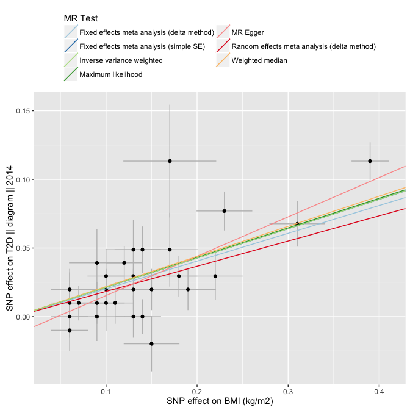

```r
mr_scatter_plot(mr_results, dat)[[1]]
```

And to test if any single SNPs are driving the association we can do two things, a forest plot of the single SNP analyses:

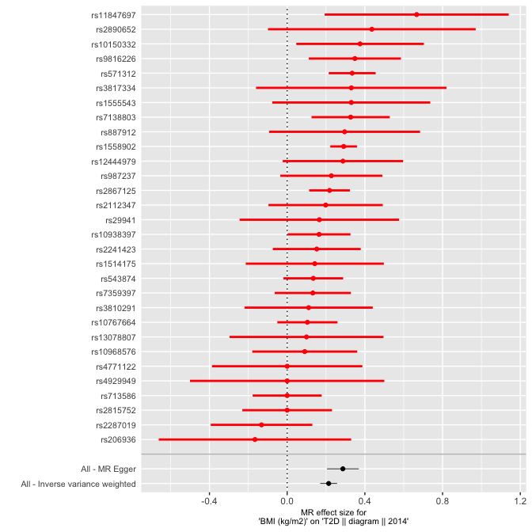

```r
mr_forest_plot(mr_singlesnp(dat))[[1]]
```

and a leave-one-out analysis:

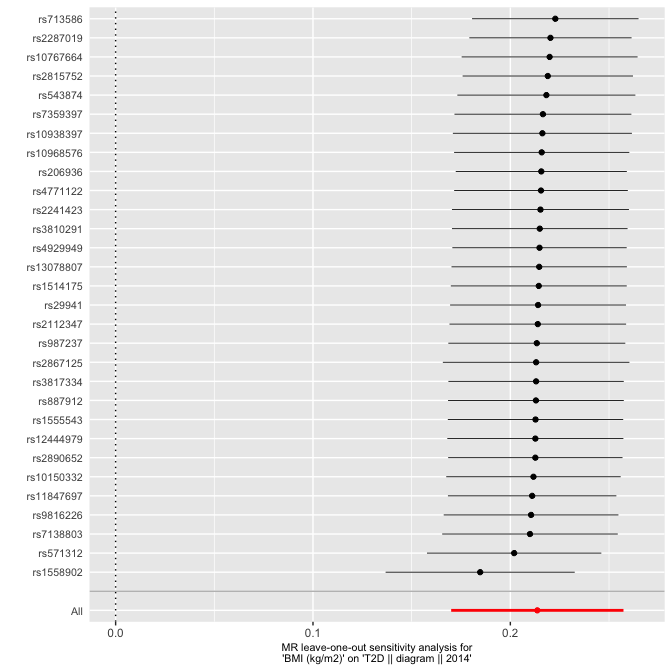

```r
mr_leaveoneout_plot(mr_leaveoneout(dat))[[1]]
```

We can also estimate heterogeneity:

```r
kable(mr_heterogeneity(dat))
```

| id.exposure | id.outcome | outcome | exposure | method | Q | Q_df | Q_pval |
| --- | --- | --- | --- | --- | --- | --- | --- |
| nRJ8CD | 6 | T2D \|\| diagram \|\| 2014 | BMI (kg/m2) | Fixed effects meta analysis (delta method) | 37.25036 | 29 | 0.1399281 |
| nRJ8CD | 6 | T2D \|\| diagram \|\| 2014 | BMI (kg/m2) | Random effects meta analysis (delta method) | 37.25036 | 29 | 0.1399281 |
| nRJ8CD | 6 | T2D \|\| diagram \|\| 2014 | BMI (kg/m2) | Maximum likelihood | 39.69577 | 29 | 0.0890353 |
| nRJ8CD | 6 | T2D \|\| diagram \|\| 2014 | BMI (kg/m2) | MR Egger | 37.34955 | 28 | 0.1113501 |
| nRJ8CD | 6 | T2D \|\| diagram \|\| 2014 | BMI (kg/m2) | Inverse variance weighted | 41.32979 | 29 | 0.0644287 |

Test for directional pleiotropy:

```r
kable(mr_pleiotropy_test(dat))
```

| id.exposure | id.outcome | outcome | exposure | egger_intercept | se | pval |
| --- | --- | --- | --- | --- | --- | --- |
| nRJ8CD | 6 | T2D \|\| diagram \|\| 2014 | BMI (kg/m2) | -0.0133015 | 0.0065768 | 0.0527718 |

And test that the direction of causality is indeed from BMI to T2D:

```r
kable(directionality_test(dat))
```

```
## Data requires p-values and sample sizes for outcomes and exposures
```

Finally, we can also perform a simple test of enrichment (are the extracted p-values more extreme than expected by chance?)

```r
kable(enrichment(dat))
```

| id.exposure | id.outcome | outcome | exposure | method | nsnp | pval |
| --- | --- | --- | --- | --- | --- | --- |
| nRJ8CD | 6 | T2D \|\| diagram \|\| 2014 | BMI (kg/m2) | Fisher’s combined test | 30 | 0 |

References

Bowden, Jack, George Davey Smith, and Stephen Burgess. 2015. “Mendelian randomization with invalid instruments: effect estimation and bias detection through Egger regression.” *International Journal of Epidemiology* In press.

Davey Smith, G., and S. Ebrahim. 2003. “’Mendelian randomization’: can genetic epidemiology contribute to understanding environmental determinants of disease?” *International Journal of Epidemiology* 32 (1): 1–22. doi:10.1093/ije/dyg070.

Davey Smith, George, and Gibran Hemani. 2014. “Mendelian randomization: genetic anchors for causal inference in epidemiological studies.” *Human Molecular Genetics* 23 (R1). Oxford Univ Press: R89—–98. doi:10.1093/hmg/ddu328.

Pierce, Brandon L, and Stephen Burgess. 2013. “Efficient design for Mendelian randomization studies: subsample and 2-sample instrumental variable estimators.” *American Journal of Epidemiology* 178 (7): 1177–84. doi:10.1093/aje/kwt084.

Speliotes, Elizabeth K, Cristen J Willer, Sonja I Berndt, Keri L Monda, Gudmar Thorleifsson, Anne U Jackson, Hana Lango Allen, et al. 2010. “Association analyses of 249,796 individuals reveal 18 new loci associated with body mass index.” *Nature Genetics* 42 (11): 937–48. doi:10.1038/ng.686.